# Network Graph Assignment

Luwei Lei

11/8/2020

```r
library(circlize, warn.conflicts = F, quietly = T)
library(tidyr, warn.conflicts = F, quietly = T)
library(dplyr, warn.conflicts = F, quietly = T)
library(data.table, warn.conflicts = F, quietly = T)
library(tibble, warn.conflicts = F, quietly = T)
library(readxl)
library(chorddiag)
```

1. You have to extract the data from this Excel file programmatically, i.e., using R and/or Python, not just copy it by hand to another Excel file. For this, you will have to open and understand the structure and format of the data in the file.

```r
columns =readxl::read_excel("data/State_to_State_Migrations_Table_2018.xls",skip = 4,n_max=3, col_names = FALSE)
```

```
## * `` -> ...1
## * `` -> ...2
## * `` -> ...3
## * `` -> ...4
## * `` -> ...5
## * ...
```

```r
#get the useful column names
columns = data.frame(t(rbind(columns, colnames(columns)))) %>%
        filter(X3  == "Estimate" &  !is.na(X2))%>%
        slice(c(2:52,54))
col =  columns  %>% .$X4 %>%as.vector
col = append(col,"...1",0)
```

2. You will need to extract the data in the form of a data frame with 3 columns: source, target and count; the last column will contain the numbers of people who migrated from the source state to the target state in 2018

```r
df=readxl::read_excel("data/State_to_State_Migrations_Table_2018.xls",skip = 4,col_names = FALSE)
```

```
## * `` -> ...1
## * `` -> ...2
## * `` -> ...3
## * `` -> ...4
## * `` -> ...5
## * ...
```

```r
df = df %>% select(col)%>%
            setnames(old = as.vector(columns$X4), as.vector( columns$X2)) %>%
            drop_na("...1") %>%
            filter( ...1 != "Current residence in")%>%
            slice(2:53) %>%
            column_to_rownames('...1')
```

```
## Note: Using an external vector in selections is ambiguous.
## ℹ Use `all_of(col)` instead of `col` to silence this message.
## ℹ See <https://tidyselect.r-lib.org/reference/faq-external-vector.html>.
```

```r
df = data.frame(reshape2::melt(as.matrix(df), value.name = "count", varnames=c('target', 'source')))
df[df == "N/A"] = 0
df$count = as.numeric(as.character(df$count))

final_df = df[df$source %in% c("New York","Texas","Virginia","Pennsylvania"),]

final_df = tibble::as_tibble(final_df) %>%
  group_by(source) %>%
  arrange(count, .by_group = TRUE) %>%
  top_n(10)
final_df$target = state.abb[match(final_df$target, state.name)]
final_df$source = state.abb[match(final_df$source, state.name)]
# levels(final_df$target) <- c(levels(final_df$target), "D.C.")
final_df$target[is.na(final_df$target)] <- "D.C."

final_df = final_df[,c("source","target","count")]
```

```r
# final_df$target = state.abb[match(final_df$target, state.name)]
# final_df$source = state.abb[match(final_df$source, state.name)]
# reorder the cols
# final_df = final_df[,c("source","target","count")]
```

3. You can now use this data frame to create a graph object using igraph (R or Python), tidygraph (R) or networkx (Python)
4. You will create a single network graph, where the width of each edge representing the number of people moving between the two states, the color of the edge denoting the state of origin, and preferably arrows denoting the direction of migration. These aspects are required. You can style other aspects of the graph as you choose to improve readability.

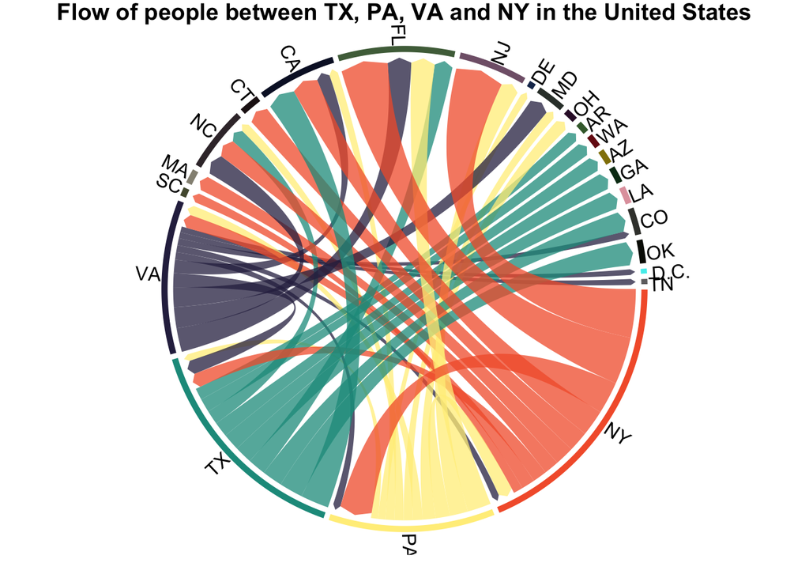

```r
# color palette
chordDiagram(
  x = final_df,
  annotationTrack = c("grid"),
  grid.col = c("NY" = "#F46036", "TX" = "#1B998B", "VA" = "#2E294E", "PA" = "#FFEE88"),
  transparency = 0.25,
  directional = 1,
  direction.type = c("arrows"),
  diffHeight  = -0.04,
  annotationTrackHeight = c(0.03, 0.01),
  link.arr.type = "big.arrow",
  link.sort = TRUE,
  link.largest.ontop = TRUE)


circos.track(track.index = 1,
             panel.fun = function(x, y) {
               circos.text(CELL_META$xcenter, CELL_META$ylim[1],
                           CELL_META$sector.index,
                           facing = "clockwise", niceFacing = TRUE, adj = c(-0.3, 0.7))

        },
        bg.border = 0.2)

title(main = "Flow of people between TX, PA, VA and NY in the United States")
```

Data Source: American Community Survey for the year 2018.  
The color represents the people flow from each of the four selected states to destination states.